# A Look At Student Alcohol Consumption

Affan Hussain

May 13, 2018

# Introduction

In this project I attempt to find a relationship between how much alcohol a student consumes and how high their grades are. I will begin by taking a dataset with relevant information and clearn it up so that it is easier to analyze. I will then do some Eploratory Data Analysis (EDA) to help me find a testable hypothesis. Lastly I will attempt to use machine learning to predict a students grades based on their alcohol consumption.

# Tools Required

For this tutorial I will be using the R programming language and RStudio as my development environment. Many of the functions used in this tutorial can be found in the Tidyverse library.

The dataset that I am using can be found at https://www.kaggle.com/uciml/student-alcohol-consumption

# 1 Getting and Cleaning our Data

When you go to https://www.kaggle.com/uciml/student-alcohol-consumption you will notice there are actually two datasets. One for students in math classes and the other for students in portuguese language classes. Download both CSV files (Comma Seperated Value files). Throughout this tutorial we use the set of tidyverse libraries which contain all the essential tools a data scientist needs. You can find more information at https://www.tidyverse.org/

```r
library(tidyverse)
#Read in the CSV files and convert them to data frames
math_df <- read.csv("student-mat.csv")
port_df <- read.csv("student-por.csv")
#Show the first 6 rows of the data frame
head(math_df)
```

```
##   school sex age address famsize Pstatus Medu Fedu     Mjob     Fjob
## 1     GP   F  18       U     GT3       A    4    4  at_home  teacher
## 2     GP   F  17       U     GT3       T    1    1  at_home    other
## 3     GP   F  15       U     LE3       T    1    1  at_home    other
## 4     GP   F  15       U     GT3       T    4    2   health services
## 5     GP   F  16       U     GT3       T    3    3    other    other
## 6     GP   M  16       U     LE3       T    4    3 services    other
##       reason guardian traveltime studytime failures schoolsup famsup paid
## 1     course   mother          2         2        0       yes     no   no
## 2     course   father          1         2        0        no    yes   no
## 3      other   mother          1         2        3       yes     no  yes
## 4       home   mother          1         3        0        no    yes  yes
## 5       home   father          1         2        0        no    yes  yes
## 6 reputation   mother          1         2        0        no    yes  yes
##   activities nursery higher internet romantic famrel freetime goout Dalc
## 1         no     yes    yes       no       no      4        3     4    1
## 2         no      no    yes      yes       no      5        3     3    1
## 3         no     yes    yes      yes       no      4        3     2    2
## 4        yes     yes    yes      yes      yes      3        2     2    1
## 5         no     yes    yes       no       no      4        3     2    1
## 6        yes     yes    yes      yes       no      5        4     2    1
##   Walc health absences G1 G2 G3
## 1    1      3        6  5  6  6
## 2    1      3        4  5  5  6
## 3    3      3       10  7  8 10
## 4    1      5        2 15 14 15
## 5    2      5        4  6 10 10
## 6    2      5       10 15 15 15
```

```r
#Show the last 6 rows of the data fram
tail(port_df)
```

```
##     school sex age address famsize Pstatus Medu Fedu     Mjob     Fjob
## 644     MS   F  18       R     GT3       T    4    4  teacher  at_home
## 645     MS   F  19       R     GT3       T    2    3 services    other
## 646     MS   F  18       U     LE3       T    3    1  teacher services
## 647     MS   F  18       U     GT3       T    1    1    other    other
## 648     MS   M  17       U     LE3       T    3    1 services services
## 649     MS   M  18       R     LE3       T    3    2 services    other
##         reason guardian traveltime studytime failures schoolsup famsup
## 644 reputation   mother          3         1        0        no    yes
## 645     course   mother          1         3        1        no     no
## 646     course   mother          1         2        0        no    yes
## 647     course   mother          2         2        0        no     no
## 648     course   mother          2         1        0        no     no
## 649     course   mother          3         1        0        no     no
##     paid activities nursery higher internet romantic famrel freetime goout
## 644   no        yes     yes    yes      yes      yes      4        4     3
## 645   no        yes      no    yes      yes       no      5        4     2
## 646   no         no     yes    yes      yes       no      4        3     4
## 647   no        yes     yes    yes       no       no      1        1     1
## 648   no         no      no    yes      yes       no      2        4     5
## 649   no         no      no    yes      yes       no      4        4     1
##     Dalc Walc health absences G1 G2 G3
## 644    2    2      5        4  7  9 10
## 645    1    2      5        4 10 11 10
## 646    1    1      1        4 15 15 16
## 647    1    1      5        6 11 12  9
## 648    3    4      2        6 10 10 10
## 649    3    4      5        4 10 11 11
```

## 1.1 About our data

Before we do any modifications to our data frames it’s important to understand whaat’s in our data. There are over 30 columns with data on the student’s family life, their social life, socio-economic status, etc. We also have two data frames and the students in each are not completely unique, according to the description on Kaggle there are 382 students who appear in both sets. We need to take care of these issues before doing any analysis.

## 1.2 Removing overlaps

We want to combine the two data frames and remove duplicate entries. We do this by first finding all the duplicates and then removing them from one of the datasets. If you think about it in terms of sets A and B we are doing (A - (A intersect B)) Union B

```r
#This finds all the duplicates based on many of the students attributes
duplicates <- merge(math_df, port_df, by=c("school","sex","age","address","famsize","Pstatus","Medu","Fedu","Mjob","Fjob","reason","nursery","internet"))

#We remove these duplicates from the math table
unique_math <- anti_join(math_df, duplicates, by=c("school","sex","age","address","famsize","Pstatus","Medu","Fedu","Mjob","Fjob","reason","nursery","internet"))

#We then add the unique students from the math table to all of the other students
students <- rbind(unique_math, port_df)

head(students)
```

```
##   school sex age address famsize Pstatus Medu Fedu     Mjob     Fjob
## 1     GP   M  18       R     GT3       T    2    2 services    other
## 2     GP   M  15       R     GT3       T    3    2    other    other
## 3     GP   M  16       U     LE3       T    1    2    other    other
## 4     GP   M  17       U     GT3       T    1    3  at_home services
## 5     GP   M  16       U     GT3       T    3    2 services services
## 6     GP   F  18       U     LE3       T    2    1 services  at_home
##       reason guardian traveltime studytime failures schoolsup famsup paid
## 1 reputation   mother          1         1        2        no    yes   no
## 2     course   mother          2         2        2       yes    yes   no
## 3     course   mother          2         1        1        no     no   no
## 4     course   father          1         1        0        no     no   no
## 5     course   mother          2         1        1        no    yes   no
## 6 reputation   mother          1         2        1        no     no   no
##   activities nursery higher internet romantic famrel freetime goout Dalc
## 1        yes     yes    yes      yes       no      3        3     3    1
## 2         no     yes    yes      yes      yes      4        4     4    1
## 3        yes     yes    yes       no       no      4        4     4    2
## 4         no     yes     no      yes       no      5        3     3    1
## 5        yes      no     no       no       no      4        5     2    1
## 6         no     yes    yes      yes      yes      5        4     3    1
##   Walc health absences G1 G2 G3
## 1    2      4        0  7  4  0
## 2    4      3        6  5  9  7
## 3    4      5        0  7  0  0
## 4    4      2        2 10 10 10
## 5    1      2       16 12 11 12
## 6    1      5       12 12 12 13
```

## 1.3 Removing extra information

Next we will remove the columns we won’t be analyzing so that it is easier to view our table. We will also rename these columns so that they are easier to read. More information about how the columns are labeled can be found on the kaggle page.

```r
#This selects the columns we want
students <- students %>% select( "Dalc", "Walc", "G1", "G2", "G3")
#This renames the columns
names(students) <- c("weekday_alc", "weekend_alc", "first_grade", "second_grade", "final_grade")

head(students)
```

```
##   weekday_alc weekend_alc first_grade second_grade final_grade
## 1           1           2           7            4           0
## 2           1           4           5            9           7
## 3           2           4           7            0           0
## 4           1           4          10           10          10
## 5           1           1          12           11          12
## 6           1           1          12           12          13
```

## 1.4 Adding an extra column

We will add a column called total_alc that gives a value for alcohol consumed during the entire week. Since the other columns take a value from 1 to 5 we will make our new column be scaled the same way. This will allow us to do more analysis later on.

```r
students <- students %>% mutate(total_alc = ceiling((weekday_alc + weekend_alc)/2))
head(students)
```

```
##   weekday_alc weekend_alc first_grade second_grade final_grade total_alc
## 1           1           2           7            4           0         2
## 2           1           4           5            9           7         3
## 3           2           4           7            0           0         3
## 4           1           4          10           10          10         3
## 5           1           1          12           11          12         1
## 6           1           1          12           12          13         1
```

# 2 Exploratory Data Analysis (EDA)

Now that we have cleaned our data we can do some exploratory data analysis (EDA). The point of EDA is to get more information about general trends and patterns in our data so that we can make testable hypotheses. We will perform two kinds of analysis: visualization and statistical measures.

## 2.1 Final grade vs Total alcohol consumption

We start off with a couple of assumptions. Let’s assume that the final grade is a good indicator of the students performance throughout the course. Let’s also assume that alcohol consumption is correlated with this final grade. We can use ggplot (a libraray from tidyverse) to graph the relevant data. You can get more information on ggplot at http://ggplot2.tidyverse.org/

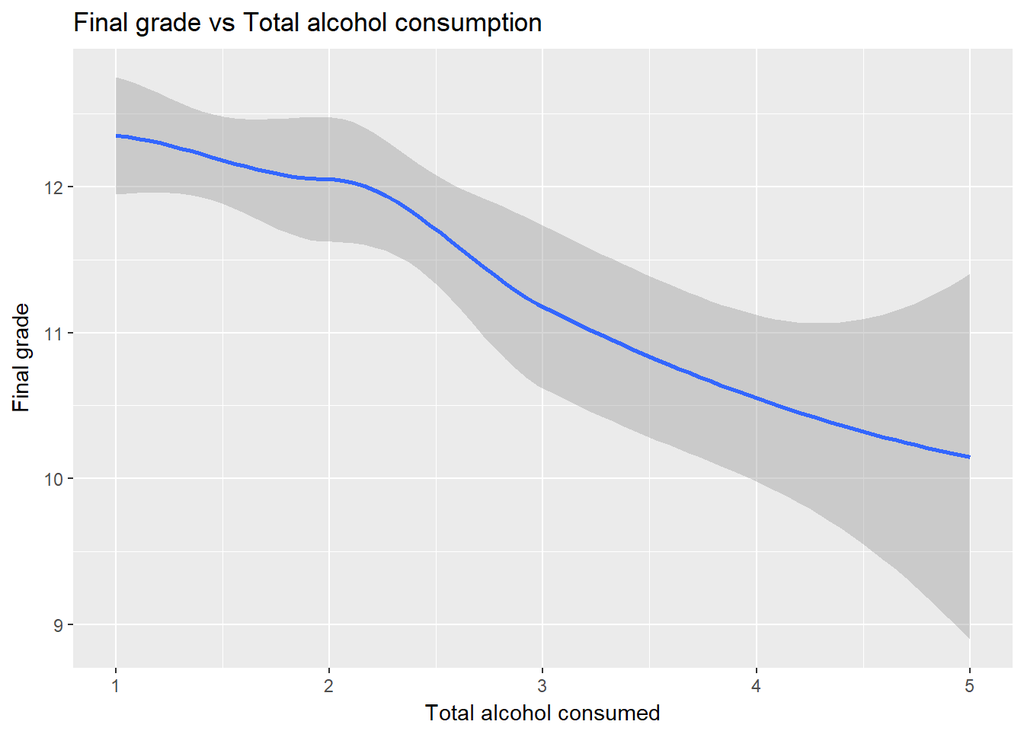

```r
students %>%
  ggplot(aes(x = total_alc, y = final_grade)) +
  geom_smooth() +
  labs(title = "Final grade vs Total alcohol consumption",
       x = "Total alcohol consumed",
       y = "Final grade")
```

From this graph we can easily see that the more alcohol a student consumes each week the lower their final grades tend to be. As you can see in the graph there is a highlighted area around the line. This area represents a 95% confidence interval at each point. Taking another look at the graph we see that the area at higher alcohol consumptions is larger. That means there is more variance in final grades at those amounts.

We can also look at some of the statistics for our data

```r
cat("The average students alcohol consumption", mean(students$total_alc), "\n")
```

```
## The average students alcohol consumption 2.063798
```

```r
cat("The average students final grade", mean(students$final_grade))
```

```
## The average students final grade 11.82344
```

We can also look at how the student’s grades are affected over time by their alcohol consumption. We will quantify their changing grades by looking at the difference between their first and second grade as well as the difference between their second and final grades.

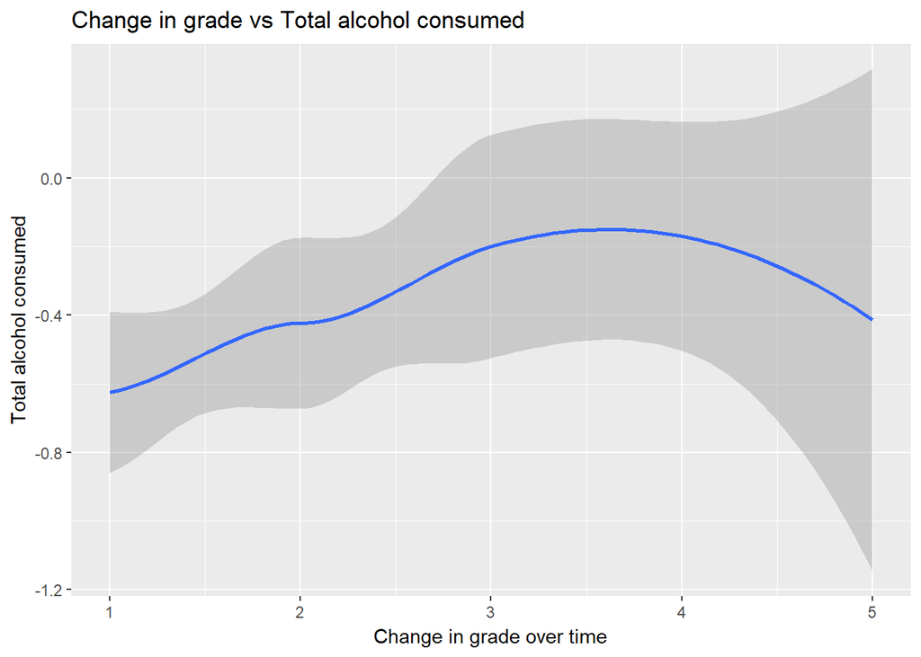

```r
students %>%
  ggplot(aes(x = total_alc, y = (first_grade  - second_grade) + (second_grade - final_grade))) +
  geom_smooth() +
  labs(title = "Change in grade vs Total alcohol consumed",
       x = "Change in grade over time",
       y = "Total alcohol consumed")
```

This graph is a little more difficult to interpret. We see that students who consume more alcohol also tend to have steadier grades compared to students who drink less alcohol. Of course this graph doesn’t take into account the actual grades. Those who drink more alcohol likely start with lower scores.

## 2.2 Skew in our data

The averages we found above aren’t in the line we calculated so this suggests that there’s some skew in our data. Let’s create histograms of both total alcohol consumption and final grades.

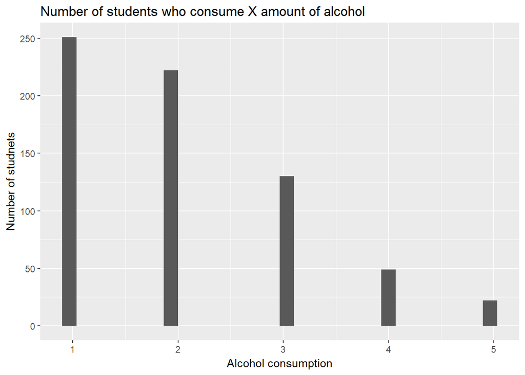

```r
students %>%
  ggplot(aes(x = total_alc)) +
  geom_histogram() +
  labs(title = "Number of students who consume X amount of alcohol",
       x = "Alcohol consumption",
       y = "Number of studnets")
```

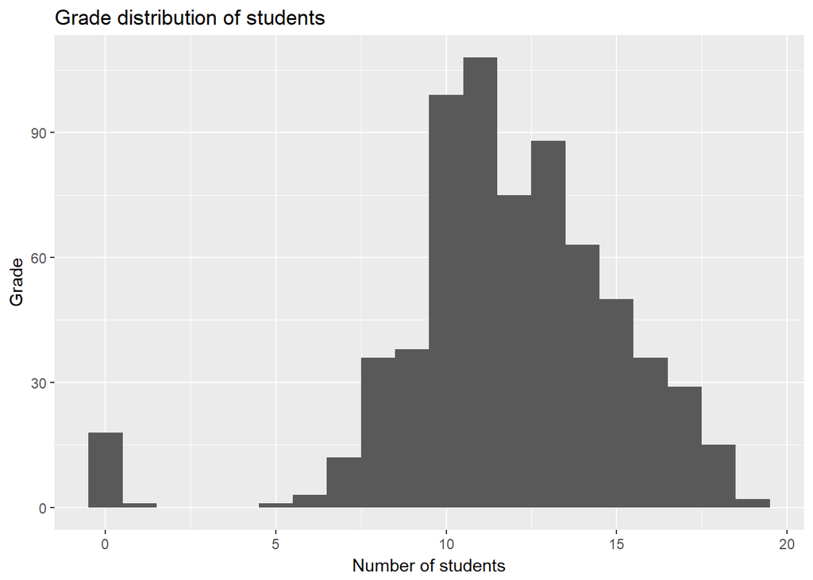

```r
students %>%
  ggplot(aes(x = final_grade)) +
  geom_histogram(binwidth = 1) +
  labs(title = "Grade distribution of students",
       x = "Number of students",
       y = "Grade")
```

From the histogram on total alcohol consumption we see that most students drink little to no alcohol. This helps explain the smaller confidence interval at lower alcohol consumptions we saw in our earlier graph.

## 2.3 Weekday vs Weekend Alcohol consumption

Now that we know there is a correlation between total alcohol consumption and grades, and we know how our data is skewed we can look for more specific correlations and interpret them correcectly. Let’s see how weekday alcohol consumption affects grades vs weekend alcohol consumption.

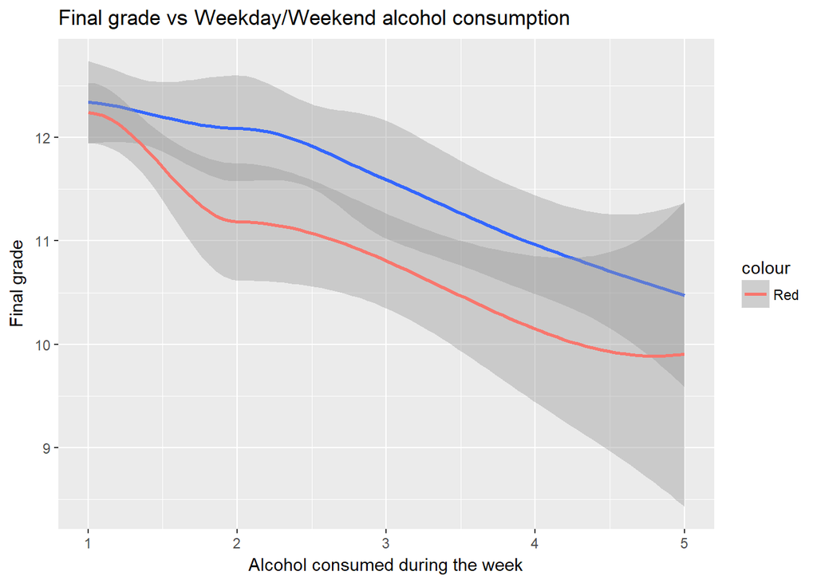

```r
students %>%
  ggplot(aes(x = weekend_alc, y = final_grade)) +
  geom_smooth() +
  geom_smooth(aes(x = weekday_alc, color = "Red")) +
  labs(title = "Final grade vs Weekday/Weekend alcohol consumption",
       x = "Alcohol consumed during the week",
       y = "Final grade")
```

In the above graph we plotted lines for both weekend and weekday alcohol consumption. Weekend alcohol consumption is in blue and Weekday alcohol consumption is in red. It is pretty clear to see that drinking during the week has a far more negative effect on students grades compared to drinking on the weekend.

## 2.4 Interaction between Weekday and Weekend drinking

We know that drinking during the week is worse for grades but is drinking during the day independant of other factors? The following graph shows us the relationship between drinking during the week and drinking on the weekend

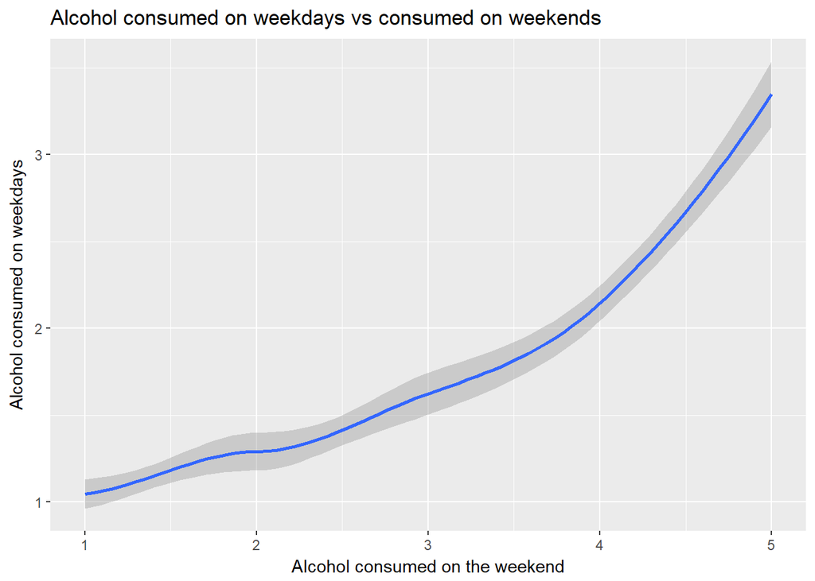

```r
students %>%
  ggplot(aes(x = weekend_alc, y = weekday_alc)) +
  geom_smooth() +
  labs(title = "Alcohol consumed on weekdays vs consumed on weekends",
       x = "Alcohol consumed on the weekend",
       y = "Alcohol consumed on weekdays")
```

Here we see that there is a correlation between alcohol consumed during the week and the amount of alcohol consumed on the weekend. What makes this graph interesting though is that it seems to grow exponentially. A student is much more likely to drink during the week if they drink a lot during the weekend.

# 3 Machine Learning

Machine learning is an application of statistics. The goal is to find a statistical model for our data and then to train that model to make predictions. In this tutorial we use supervised machine learning. We will train the model using a dataset then check the accuracy with a test data set. Our model is going to predict final grades based on alcohol consumed throughout the week (weekdays and weekends)

## 3.1 Linear regression

We will be using a linear regression model for this tutorial. From our EDA graphs above we see that most of our relationships are linear. The other benefit of using a linear regression model is that they tend to be easier to interpret, we can look at the betas to gain some understanding on the relationship between variables. To learn more about linear regression for machine learning visit https://machinelearningmastery.com/linear-regression-for-machine-learning/

```r
model = lm(final_grade ~ weekday_alc + weekend_alc  , data = students)
model
```

```
##
## Call:
## lm(formula = final_grade ~ weekday_alc + weekend_alc, data = students)
##
## Coefficients:
## (Intercept)  weekday_alc  weekend_alc
##     13.1473      -0.5376      -0.2270
```

As we can see from the coefficients weekday alcohol consumption has a greater negative effect on grades compared to weekend alcohol consumption, this is consistent with what we discovered earlier.

## 3.2 Cross validation

Now that we have a model we want to test it. We can do this using cross validation. Basically we recreate the model with a random sampling of the data then we use the rest of the data as a testing set. We will use 5-fold cross validation to test our model.

```r
set.seed(1234)

library(caret)
# create the cross-validation partition
result_df <- createFolds(students$final_grade, k=5) %>%
  # fit models and gather results
  purrr::imap(function(test_indices, fold_number) {
    # split into train and test for the fold
    train_df <- students %>%
      select(final_grade, weekday_alc, weekend_alc) %>%
      slice(-test_indices)

    test_df <- students %>%
      select(final_grade, weekday_alc, weekend_alc) %>%
      slice(test_indices)

    # fit the two models
    reg1 <- lm(final_grade~weekday_alc + weekend_alc, data=train_df)

    # gather results
    test_df %>%
      select(actual_final_grade = final_grade) %>%
      mutate(fold=fold_number) %>%
      mutate(predicted = predict(reg1, newdata=test_df))
}) %>%
  # combine the five result data frames into one
  purrr::reduce(bind_rows)
head(result_df)
```

```
## # A tibble: 6 x 3
##   actual_final_grade fold  predicted
##                <int> <chr>     <dbl>
## 1                  7 Fold1      11.5
## 2                 13 Fold1      12.5
## 3                 13 Fold1      12.5
## 4                 11 Fold1      11.7
## 5                 13 Fold1      12.1
## 6                 11 Fold1      12.5
```

# 4 Conclusion

There is a correlation between drinking alcohol and grades. The more a student drinks the lower their final grades tend to be. We also know that drinking during the week is far worse than drinking on the weekends.

This dataset is very rich and there is a lot more interesting questions we can ask. We can examine how a student’s home life affects how likely they are to drink. Is socio-economic class more important than alcohol consumption when predicting final grades? I encourage you to use this data set to explore these questions and many others.

# Further Reading

- Caret Library http://topepo.github.io/caret/index.html
- EDA http://www.stat.cmu.edu/~hseltman/309/Book/chapter4.pdf
- GGplot http://ggplot2.tidyverse.org/
- Linear Regression https://machinelearningmastery.com/linear-regression-for-machine-learning/
- Tidyverse https://www.tidyverse.org/